# Risk Factor Analysis

## Outcome Variable

**Outcome Variable:** pers_wasted624

## Predictor Variables

**Intervention Variable:** ever_sunderweight06

**Adjustment Set:**

- sex
- arm
- brthmon
- vagbrth
- single
- W_mage
- W_mhtcm
- W_mwtkg
- W_mbmi
- W_meducyrs
- W_feducyrs
- W_parity
- delta_brthmon
- delta_vagbrth
- delta_single
- delta_W_mage
- delta_W_mhtcm
- delta_W_mwtkg
- delta_W_mbmi
- delta_W_meducyrs
- delta_W_feducyrs
- delta_W_parity

## Stratifying Variables

The analysis was stratified on these variable(s):

- studyid
- country

## Data Summary

| studyid | country | ever_sunderweight06 | pers_wasted624 | n_cell | n |
| --- | --- | --- | --- | --- | --- |
| CMC-V-BCS-2002 | INDIA | 0 | 0 | 285 | 373 |
| CMC-V-BCS-2002 | INDIA | 0 | 1 | 12 | 373 |
| CMC-V-BCS-2002 | INDIA | 1 | 0 | 60 | 373 |
| CMC-V-BCS-2002 | INDIA | 1 | 1 | 16 | 373 |
| CMIN | BANGLADESH | 0 | 0 | 194 | 252 |
| CMIN | BANGLADESH | 0 | 1 | 11 | 252 |
| CMIN | BANGLADESH | 1 | 0 | 33 | 252 |
| CMIN | BANGLADESH | 1 | 1 | 14 | 252 |
| COHORTS | GUATEMALA | 0 | 0 | 904 | 1023 |
| COHORTS | GUATEMALA | 0 | 1 | 20 | 1023 |
| COHORTS | GUATEMALA | 1 | 0 | 78 | 1023 |
| COHORTS | GUATEMALA | 1 | 1 | 21 | 1023 |
| COHORTS | INDIA | 0 | 0 | 5698 | 6897 |
| COHORTS | INDIA | 0 | 1 | 423 | 6897 |
| COHORTS | INDIA | 1 | 0 | 428 | 6897 |
| COHORTS | INDIA | 1 | 1 | 348 | 6897 |
| COHORTS | PHILIPPINES | 0 | 0 | 2460 | 2809 |
| COHORTS | PHILIPPINES | 0 | 1 | 154 | 2809 |
| COHORTS | PHILIPPINES | 1 | 0 | 123 | 2809 |
| COHORTS | PHILIPPINES | 1 | 1 | 72 | 2809 |
| CONTENT | PERU | 0 | 0 | 213 | 215 |
| CONTENT | PERU | 0 | 1 | 0 | 215 |
| CONTENT | PERU | 1 | 0 | 2 | 215 |
| CONTENT | PERU | 1 | 1 | 0 | 215 |
| EE | PAKISTAN | 0 | 0 | 207 | 374 |
| EE | PAKISTAN | 0 | 1 | 9 | 374 |
| EE | PAKISTAN | 1 | 0 | 118 | 374 |
| EE | PAKISTAN | 1 | 1 | 40 | 374 |
| GMS-Nepal | NEPAL | 0 | 0 | 437 | 590 |
| GMS-Nepal | NEPAL | 0 | 1 | 70 | 590 |

[output cut: 90 more lines]

The following strata were considered:

- studyid: CMC-V-BCS-2002, country: INDIA
- studyid: CMIN, country: BANGLADESH
- studyid: COHORTS, country: GUATEMALA
- studyid: COHORTS, country: INDIA
- studyid: COHORTS, country: PHILIPPINES
- studyid: CONTENT, country: PERU
- studyid: EE, country: PAKISTAN
- studyid: GMS-Nepal, country: NEPAL
- studyid: Guatemala BSC, country: GUATEMALA
- studyid: IRC, country: INDIA
- studyid: JiVitA-3, country: BANGLADESH
- studyid: JiVitA-4, country: BANGLADESH
- studyid: Keneba, country: GAMBIA
- studyid: LCNI-5, country: MALAWI
- studyid: MAL-ED, country: BANGLADESH
- studyid: MAL-ED, country: BRAZIL
- studyid: MAL-ED, country: INDIA
- studyid: MAL-ED, country: NEPAL
- studyid: MAL-ED, country: PERU
- studyid: MAL-ED, country: SOUTH AFRICA
- studyid: MAL-ED, country: TANZANIA, UNITED REPUBLIC OF
- studyid: NIH-Birth, country: BANGLADESH
- studyid: NIH-Crypto, country: BANGLADESH
- studyid: PROBIT, country: BELARUS
- studyid: PROVIDE, country: BANGLADESH
- studyid: ResPak, country: PAKISTAN
- studyid: SAS-CompFeed, country: INDIA
- studyid: SAS-FoodSuppl, country: INDIA
- studyid: TanzaniaChild2, country: TANZANIA, UNITED REPUBLIC OF
- studyid: ZVITAMBO, country: ZIMBABWE

### Dropped Strata

Some strata were dropped due to rare outcomes:

- studyid: CONTENT, country: PERU
- studyid: Guatemala BSC, country: GUATEMALA
- studyid: MAL-ED, country: BANGLADESH
- studyid: MAL-ED, country: BRAZIL
- studyid: MAL-ED, country: NEPAL
- studyid: MAL-ED, country: PERU
- studyid: MAL-ED, country: SOUTH AFRICA
- studyid: MAL-ED, country: TANZANIA, UNITED REPUBLIC OF
- studyid: PROBIT, country: BELARUS

## Methods Detail

We’re interested in the causal parameters $E[Y_a]$ for all values of $a \in \mathcal{A}$. These parameters represent the mean outcome if, possibly contrary to fact, we intervened to set all units to have $A=a$. Under the randomization and positivity assumptions, these are identified by the statistical parameters $\psi_a=E_W[E_{Y|A,W}(Y|A=a,W)]$. In addition, we’re interested in the mean of $Y$, $E[Y]$ under no intervention (the observed mean). We will estimate these parameters by using SuperLearner to fit the relevant likelihood factors – $E_{Y|A,W}(Y|A=a,W)$ and $p(A=a|W)$, and then updating our likelihood fit using a joint TMLE.

For unadjusted analyses ($W=\{\}$), initial likelihoods were estimated using Lrnr_glm to estimate the simple $E(Y|A)$ and Lrnr_mean to estimate $p(A)$. For adjusted analyses, a small library containing Lrnr_glmnet, Lrnr_xgboost, and Lrnr_mean was used.

Having estimated these parameters, we will then use the delta method to estimate relative risks and attributable risks relative to a prespecified baseline level of $A$.

# Results Detail

## Results Plots

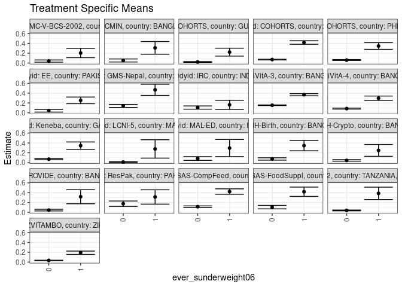

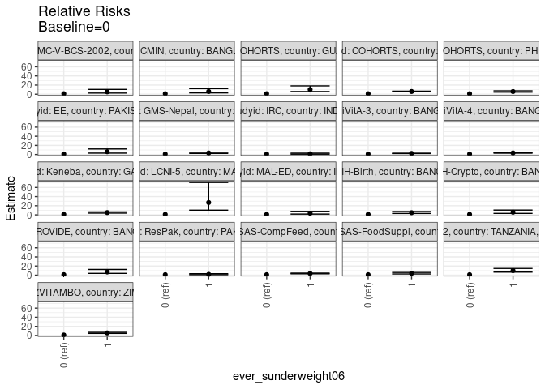

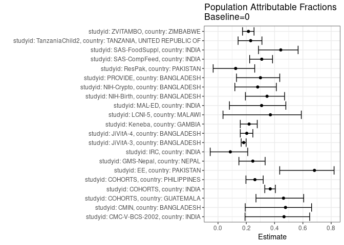

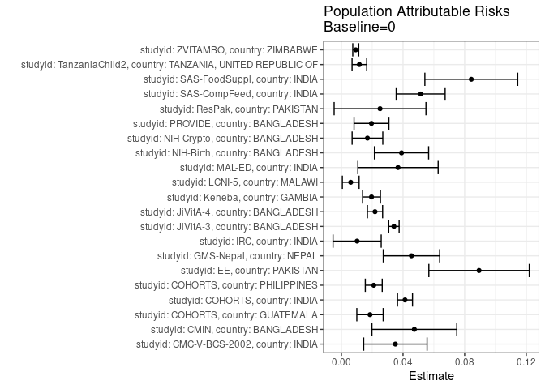

## Results Table

### Parameter: TSM

| studyid | country | intervention_level | baseline_level | estimate | ci_lower | ci_upper |
| --- | --- | --- | --- | --- | --- | --- |
| CMC-V-BCS-2002 | INDIA | 0 | NA | 0.0400370 | 0.0177925 | 0.0622815 |
| CMC-V-BCS-2002 | INDIA | 1 | NA | 0.2039186 | 0.1092960 | 0.2985412 |
| CMIN | BANGLADESH | 0 | NA | 0.0518630 | 0.0210352 | 0.0826908 |
| CMIN | BANGLADESH | 1 | NA | 0.3084106 | 0.1795137 | 0.4373076 |
| COHORTS | GUATEMALA | 0 | NA | 0.0215197 | 0.0121162 | 0.0309232 |
| COHORTS | GUATEMALA | 1 | NA | 0.2218032 | 0.1408695 | 0.3027370 |
| COHORTS | INDIA | 0 | NA | 0.0705101 | 0.0640554 | 0.0769648 |
| COHORTS | INDIA | 1 | NA | 0.4174396 | 0.3816687 | 0.4532104 |
| COHORTS | PHILIPPINES | 0 | NA | 0.0594562 | 0.0504274 | 0.0684850 |
| COHORTS | PHILIPPINES | 1 | NA | 0.3466048 | 0.2782132 | 0.4149965 |
| EE | PAKISTAN | 0 | NA | 0.0416667 | 0.0149824 | 0.0683509 |
| EE | PAKISTAN | 1 | NA | 0.2531646 | 0.1852731 | 0.3210560 |
| GMS-Nepal | NEPAL | 0 | NA | 0.1392789 | 0.1092314 | 0.1693263 |
| GMS-Nepal | NEPAL | 1 | NA | 0.4675486 | 0.3538425 | 0.5812547 |
| IRC | INDIA | 0 | NA | 0.1068763 | 0.0740923 | 0.1396603 |
| IRC | INDIA | 1 | NA | 0.1624072 | 0.0691902 | 0.2556243 |
| JiVitA-3 | BANGLADESH | 0 | NA | 0.1538225 | 0.1472987 | 0.1603464 |
| JiVitA-3 | BANGLADESH | 1 | NA | 0.3685155 | 0.3467830 | 0.3902480 |
| JiVitA-4 | BANGLADESH | 0 | NA | 0.0855361 | 0.0755904 | 0.0954817 |
| JiVitA-4 | BANGLADESH | 1 | NA | 0.2969745 | 0.2527902 | 0.3411587 |
| Keneba | GAMBIA | 0 | NA | 0.0693586 | 0.0589003 | 0.0798169 |
| Keneba | GAMBIA | 1 | NA | 0.3448890 | 0.2698495 | 0.4199284 |
| LCNI-5 | MALAWI | 0 | NA | 0.0102828 | 0.0031722 | 0.0173933 |
| LCNI-5 | MALAWI | 1 | NA | 0.2777778 | 0.0904991 | 0.4650565 |
| MAL-ED | INDIA | 0 | NA | 0.0824114 | 0.0443081 | 0.1205146 |
| MAL-ED | INDIA | 1 | NA | 0.2955786 | 0.1214280 | 0.4697292 |
| NIH-Birth | BANGLADESH | 0 | NA | 0.0735212 | 0.0496379 | 0.0974045 |
| NIH-Birth | BANGLADESH | 1 | NA | 0.3449745 | 0.2399137 | 0.4500353 |
| NIH-Crypto | BANGLADESH | 0 | NA | 0.0433651 | 0.0280227 | 0.0587075 |
| NIH-Crypto | BANGLADESH | 1 | NA | 0.2475409 | 0.1267922 | 0.3682895 |
| PROVIDE | BANGLADESH | 0 | NA | 0.0455207 | 0.0284235 | 0.0626179 |
| PROVIDE | BANGLADESH | 1 | NA | 0.3175770 | 0.1748038 | 0.4603501 |
| ResPak | PAKISTAN | 0 | NA | 0.1757736 | 0.1210591 | 0.2304882 |
| ResPak | PAKISTAN | 1 | NA | 0.3129731 | 0.1670392 | 0.4589069 |
| SAS-CompFeed | INDIA | 0 | NA | 0.1148618 | 0.0989402 | 0.1307834 |
| SAS-CompFeed | INDIA | 1 | NA | 0.4231323 | 0.3681306 | 0.4781339 |
| SAS-FoodSuppl | INDIA | 0 | NA | 0.1056926 | 0.0703542 | 0.1410309 |
| SAS-FoodSuppl | INDIA | 1 | NA | 0.4194072 | 0.3247041 | 0.5141102 |
| TanzaniaChild2 | TANZANIA, UNITED REPUBLIC OF | 0 | NA | 0.0388761 | 0.0303105 | 0.0474417 |
| TanzaniaChild2 | TANZANIA, UNITED REPUBLIC OF | 1 | NA | 0.3864588 | 0.2607293 | 0.5121884 |
| ZVITAMBO | ZIMBABWE | 0 | NA | 0.0339654 | 0.0304574 | 0.0374735 |
| ZVITAMBO | ZIMBABWE | 1 | NA | 0.1901966 | 0.1562431 | 0.2241500 |

### Parameter: E(Y)

| studyid | country | intervention_level | baseline_level | estimate | ci_lower | ci_upper |
| --- | --- | --- | --- | --- | --- | --- |
| CMC-V-BCS-2002 | INDIA | NA | NA | 0.0750670 | 0.0482904 | 0.1018437 |
| CMIN | BANGLADESH | NA | NA | 0.0992063 | 0.0622241 | 0.1361886 |
| COHORTS | GUATEMALA | NA | NA | 0.0400782 | 0.0280529 | 0.0521035 |
| COHORTS | INDIA | NA | NA | 0.1117877 | 0.1043506 | 0.1192249 |
| COHORTS | PHILIPPINES | NA | NA | 0.0804557 | 0.0703953 | 0.0905161 |
| EE | PAKISTAN | NA | NA | 0.1310160 | 0.0967738 | 0.1652583 |
| GMS-Nepal | NEPAL | NA | NA | 0.1847458 | 0.1534039 | 0.2160876 |
| IRC | INDIA | NA | NA | 0.1170732 | 0.0859146 | 0.1482317 |
| JiVitA-3 | BANGLADESH | NA | NA | 0.1879125 | 0.1813641 | 0.1944608 |
| JiVitA-4 | BANGLADESH | NA | NA | 0.1073532 | 0.0971813 | 0.1175251 |
| Keneba | GAMBIA | NA | NA | 0.0888980 | 0.0776057 | 0.1001903 |
| LCNI-5 | MALAWI | NA | NA | 0.0163317 | 0.0075211 | 0.0251422 |
| MAL-ED | INDIA | NA | NA | 0.1191489 | 0.0776405 | 0.1606574 |
| NIH-Birth | BANGLADESH | NA | NA | 0.1125461 | 0.0859151 | 0.1391771 |
| NIH-Crypto | BANGLADESH | NA | NA | 0.0602740 | 0.0429977 | 0.0775502 |
| PROVIDE | BANGLADESH | NA | NA | 0.0650407 | 0.0455353 | 0.0845460 |
| ResPak | PAKISTAN | NA | NA | 0.2008547 | 0.1494120 | 0.2522974 |
| SAS-CompFeed | INDIA | NA | NA | 0.1663067 | 0.1478935 | 0.1847199 |
| SAS-FoodSuppl | INDIA | NA | NA | 0.1900000 | 0.1515071 | 0.2284929 |
| TanzaniaChild2 | TANZANIA, UNITED REPUBLIC OF | NA | NA | 0.0505451 | 0.0409848 | 0.0601054 |
| ZVITAMBO | ZIMBABWE | NA | NA | 0.0432772 | 0.0394419 | 0.0471125 |

### Parameter: RR

| studyid | country | intervention_level | baseline_level | estimate | ci_lower | ci_upper |
| --- | --- | --- | --- | --- | --- | --- |
| CMC-V-BCS-2002 | INDIA | 0 | 0 | 1.000000 | 1.000000 | 1.000000 |
| CMC-V-BCS-2002 | INDIA | 1 | 0 | 5.093256 | 2.461926 | 10.536977 |
| CMIN | BANGLADESH | 0 | 0 | 1.000000 | 1.000000 | 1.000000 |
| CMIN | BANGLADESH | 1 | 0 | 5.946637 | 2.887262 | 12.247760 |
| COHORTS | GUATEMALA | 0 | 0 | 1.000000 | 1.000000 | 1.000000 |
| COHORTS | GUATEMALA | 1 | 0 | 10.306977 | 5.843536 | 18.179708 |
| COHORTS | INDIA | 0 | 0 | 1.000000 | 1.000000 | 1.000000 |
| COHORTS | INDIA | 1 | 0 | 5.920278 | 5.224095 | 6.709236 |
| COHORTS | PHILIPPINES | 0 | 0 | 1.000000 | 1.000000 | 1.000000 |
| COHORTS | PHILIPPINES | 1 | 0 | 5.829582 | 4.547231 | 7.473564 |
| EE | PAKISTAN | 0 | 0 | 1.000000 | 1.000000 | 1.000000 |
| EE | PAKISTAN | 1 | 0 | 6.075949 | 3.034466 | 12.165952 |
| GMS-Nepal | NEPAL | 0 | 0 | 1.000000 | 1.000000 | 1.000000 |
| GMS-Nepal | NEPAL | 1 | 0 | 3.356924 | 2.423396 | 4.650061 |
| IRC | INDIA | 0 | 0 | 1.000000 | 1.000000 | 1.000000 |
| IRC | INDIA | 1 | 0 | 1.519581 | 0.792401 | 2.914089 |
| JiVitA-3 | BANGLADESH | 0 | 0 | 1.000000 | 1.000000 | 1.000000 |
| JiVitA-3 | BANGLADESH | 1 | 0 | 2.395718 | 2.229806 | 2.573976 |
| JiVitA-4 | BANGLADESH | 0 | 0 | 1.000000 | 1.000000 | 1.000000 |
| JiVitA-4 | BANGLADESH | 1 | 0 | 3.471921 | 2.870457 | 4.199412 |
| Keneba | GAMBIA | 0 | 0 | 1.000000 | 1.000000 | 1.000000 |
| Keneba | GAMBIA | 1 | 0 | 4.972547 | 3.817541 | 6.477003 |
| LCNI-5 | MALAWI | 0 | 0 | 1.000000 | 1.000000 | 1.000000 |
| LCNI-5 | MALAWI | 1 | 0 | 27.013889 | 10.283843 | 70.960845 |
| MAL-ED | INDIA | 0 | 0 | 1.000000 | 1.000000 | 1.000000 |
| MAL-ED | INDIA | 1 | 0 | 3.586624 | 1.691694 | 7.604137 |
| NIH-Birth | BANGLADESH | 0 | 0 | 1.000000 | 1.000000 | 1.000000 |
| NIH-Birth | BANGLADESH | 1 | 0 | 4.692178 | 3.004256 | 7.328447 |
| NIH-Crypto | BANGLADESH | 0 | 0 | 1.000000 | 1.000000 | 1.000000 |
| NIH-Crypto | BANGLADESH | 1 | 0 | 5.708296 | 3.122294 | 10.436124 |
| PROVIDE | BANGLADESH | 0 | 0 | 1.000000 | 1.000000 | 1.000000 |
| PROVIDE | BANGLADESH | 1 | 0 | 6.976539 | 3.888118 | 12.518162 |
| ResPak | PAKISTAN | 0 | 0 | 1.000000 | 1.000000 | 1.000000 |
| ResPak | PAKISTAN | 1 | 0 | 1.780546 | 1.011464 | 3.134414 |
| SAS-CompFeed | INDIA | 0 | 0 | 1.000000 | 1.000000 | 1.000000 |
| SAS-CompFeed | INDIA | 1 | 0 | 3.683838 | 3.046320 | 4.454774 |
| SAS-FoodSuppl | INDIA | 0 | 0 | 1.000000 | 1.000000 | 1.000000 |
| SAS-FoodSuppl | INDIA | 1 | 0 | 3.968181 | 2.650147 | 5.941731 |
| TanzaniaChild2 | TANZANIA, UNITED REPUBLIC OF | 0 | 0 | 1.000000 | 1.000000 | 1.000000 |
| TanzaniaChild2 | TANZANIA, UNITED REPUBLIC OF | 1 | 0 | 9.940775 | 6.710225 | 14.726630 |
| ZVITAMBO | ZIMBABWE | 0 | 0 | 1.000000 | 1.000000 | 1.000000 |
| ZVITAMBO | ZIMBABWE | 1 | 0 | 5.599708 | 4.556631 | 6.881560 |

### Parameter: PAR

| studyid | country | intervention_level | baseline_level | estimate | ci_lower | ci_upper |
| --- | --- | --- | --- | --- | --- | --- |
| CMC-V-BCS-2002 | INDIA | 0 | NA | 0.0350300 | 0.0144583 | 0.0556018 |
| CMIN | BANGLADESH | 0 | NA | 0.0473433 | 0.0198029 | 0.0748837 |
| COHORTS | GUATEMALA | 0 | NA | 0.0185585 | 0.0100041 | 0.0271129 |
| COHORTS | INDIA | 0 | NA | 0.0412776 | 0.0364070 | 0.0461482 |
| COHORTS | PHILIPPINES | 0 | NA | 0.0209995 | 0.0155064 | 0.0264926 |
| EE | PAKISTAN | 0 | NA | 0.0893494 | 0.0567594 | 0.1219393 |
| GMS-Nepal | NEPAL | 0 | NA | 0.0454669 | 0.0271684 | 0.0637654 |
| IRC | INDIA | 0 | NA | 0.0101969 | -0.0054386 | 0.0258323 |
| JiVitA-3 | BANGLADESH | 0 | NA | 0.0340899 | 0.0307099 | 0.0374700 |
| JiVitA-4 | BANGLADESH | 0 | NA | 0.0218171 | 0.0168887 | 0.0267456 |
| Keneba | GAMBIA | 0 | NA | 0.0195394 | 0.0137425 | 0.0253363 |
| LCNI-5 | MALAWI | 0 | NA | 0.0060489 | 0.0006088 | 0.0114889 |
| MAL-ED | INDIA | 0 | NA | 0.0367376 | 0.0106797 | 0.0627954 |
| NIH-Birth | BANGLADESH | 0 | NA | 0.0390249 | 0.0214370 | 0.0566129 |
| NIH-Crypto | BANGLADESH | 0 | NA | 0.0169089 | 0.0069541 | 0.0268637 |
| PROVIDE | BANGLADESH | 0 | NA | 0.0195199 | 0.0082047 | 0.0308352 |
| ResPak | PAKISTAN | 0 | NA | 0.0250811 | -0.0047237 | 0.0548859 |
| SAS-CompFeed | INDIA | 0 | NA | 0.0514449 | 0.0355616 | 0.0673282 |
| SAS-FoodSuppl | INDIA | 0 | NA | 0.0843074 | 0.0541715 | 0.1144434 |
| TanzaniaChild2 | TANZANIA, UNITED REPUBLIC OF | 0 | NA | 0.0116690 | 0.0069194 | 0.0164185 |
| ZVITAMBO | ZIMBABWE | 0 | NA | 0.0093118 | 0.0073755 | 0.0112481 |

### Parameter: PAF

| studyid | country | intervention_level | baseline_level | estimate | ci_lower | ci_upper |
| --- | --- | --- | --- | --- | --- | --- |
| CMC-V-BCS-2002 | INDIA | 0 | NA | 0.4666501 | 0.1910381 | 0.6483616 |
| CMIN | BANGLADESH | 0 | NA | 0.4772206 | 0.1923743 | 0.6616027 |
| COHORTS | GUATEMALA | 0 | NA | 0.4630568 | 0.2684801 | 0.6058781 |
| COHORTS | INDIA | 0 | NA | 0.3692498 | 0.3307355 | 0.4055478 |
| COHORTS | PHILIPPINES | 0 | NA | 0.2610067 | 0.1974633 | 0.3195188 |
| EE | PAKISTAN | 0 | NA | 0.6819728 | 0.4362210 | 0.8206012 |
| GMS-Nepal | NEPAL | 0 | NA | 0.2461052 | 0.1476307 | 0.3332030 |
| IRC | INDIA | 0 | NA | 0.0870981 | -0.0551700 | 0.2101843 |
| JiVitA-3 | BANGLADESH | 0 | NA | 0.1814139 | 0.1638157 | 0.1986417 |
| JiVitA-4 | BANGLADESH | 0 | NA | 0.2032276 | 0.1575854 | 0.2463970 |
| Keneba | GAMBIA | 0 | NA | 0.2197955 | 0.1574955 | 0.2774887 |
| LCNI-5 | MALAWI | 0 | NA | 0.3703777 | 0.0352375 | 0.5890965 |
| MAL-ED | INDIA | 0 | NA | 0.3083332 | 0.0806727 | 0.4796163 |
| NIH-Birth | BANGLADESH | 0 | NA | 0.3467462 | 0.1937966 | 0.4706788 |
| NIH-Crypto | BANGLADESH | 0 | NA | 0.2805335 | 0.1190686 | 0.4124037 |
| PROVIDE | BANGLADESH | 0 | NA | 0.3001191 | 0.1306526 | 0.4365505 |
| ResPak | PAKISTAN | 0 | NA | 0.1248718 | -0.0342234 | 0.2594933 |
| SAS-CompFeed | INDIA | 0 | NA | 0.3093376 | 0.2237093 | 0.3855206 |
| SAS-FoodSuppl | INDIA | 0 | NA | 0.4437234 | 0.2863154 | 0.5664139 |
| TanzaniaChild2 | TANZANIA, UNITED REPUBLIC OF | 0 | NA | 0.2308625 | 0.1420193 | 0.3105061 |
| ZVITAMBO | ZIMBABWE | 0 | NA | 0.2151659 | 0.1733650 | 0.2548531 |